# Comparison of Original and Re-designed Visualizations: Addressing Drawbacks for Improved Clarity

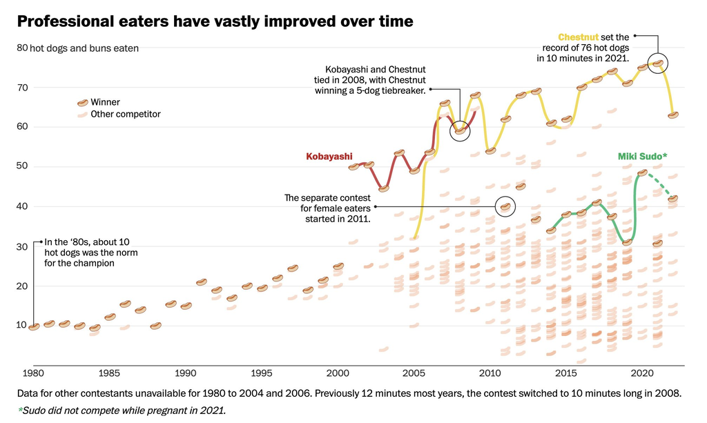

# **The current visualization’s has following shortcomings:**

**1. Overlapping of Competitor Data:** When one or two competitors dominate (e.g., Joey Chestnut), insights are unclear when all competitors’ results are crowded onto a single plot in the original chart. It becomes difficult to distinguish between competitors who consume fewer hot dogs.

**2. ImproperGender Segmentation:** Male and female rivals are not properly separated in the original chart. We can see that the performances of the male and female competitors are inconsistent, which makes it challenging to identify patterns for the female competitors.

**4.Limited Information on Female rivals:** Although Miki Sudo is singled out, there’s no information regarding the overall advancement of female rivals over time.

# **1.Visualization1**:

**Facet wrapping by gender**

[figure not shown]

**1. Faceted Line Plot by Gender and Competitor**

This plot addresses the clutter in the original graph by separating trends for male and female competitors while still showing the individual performances of key competitors (Joey Chestnut, Kobayashi, Miki Sudo, etc.). **Explanation:**

- **Faceting by gender** allows clear comparison between male and female competitors without cluttering the main plot.
- **Free y-scales** for each gender ensure that the scale adapts to the data range of male and female competitors.
- Important milestones for each competitor are labeled with their maximum achievements.
- This visualization makes it easier to track both the dominance of Joey Chestnut and Miki Sudo, while showing how other competitors have performed in comparison.

# 2.VISUALIZATION-2

  **Stacked Area Plot (Cumulative Trends for Competitors Over Time)**

[figure not shown]

  A stacked area map illustrates how the overall quantity of hot dogs consumed has increased over time, giving a visual depiction of cumulative performance. The contributions of each rival are displayed as discrete areas, highlighting periods of dominance.
- **Justification:**
- • Stacked area charts illustrate the annual growth in the overall number of hot dogs consumed by rivals.• The contributions of each contestant are distinguished by color, making it possible for you to see how many hot dogs each competitor has consumed overall.  
  Joey Chestnut’s domination over the years and the other competitors’ contributions to the overall performance become evident.

# **Why These Two Visualizations?**

**1. Faceted Line Plot:**

- This representation clearly separates male and female rivals, making it easy to analyze trends without overlap.The unconstrained y-axis eliminates distortions between male and female performance, allowing for more equitable comparisons.
- Joey Chestnut and Miki Sudo clearly dominate their respective categories.

**2.Stacked Area Plot:**

- The stacked area plot shows the cumulative growth of competitive eating performances over time, highlighting individual competitors’ contributions to overall totals.
- It’s an intuitive way to show how much each competitor has “dominated” certain years relative to others.
- Area proportions highlight noteworthy trends, such as top performers Joey Chestnut or Kobayashi, or Miki Sudo’s performance compared to other female rivals.

These two forms of visualization not only preserve the original data but also facilitate the analysis of gender-specific patterns, competitor dominance, and overall competitive performance advancement over time. Please let me know if you have any suggestions for improving these visualizations or if you require any additional information about implementation!